# Individual Differences

```
 [1] "P13" "P14" "P15" "P16" "P17" "P18" "P19" "P20" "P22" "P23" "P24" "P26" "P27" "P28" "P29"
[16] "P30" "P31" "P32" "P33" "P34" "P35" "P36" "P37" "P38" "P39" "P40" "P42" "P43" "P44" "P45"
[31] "P46" "P47" "P48" "P49" "P50" "P52" "P53" "P54" "P55" "P56" "P57" "P58"
```

# Overview of the notebook

This notebook looks at how personal traits (PC and EC) affect any benefits of novelty or curiosity on memory.

There are several ways of doing this:

1. First of all, the trait scores can be the PC score or EC score or the mean of the two (`as a general score for curiosity as a trait?`).
2. Traits’ influence on **novelty** effects.
   - This can be done by examining the interaction between the PC/EC/mean scores and *Novelty* in a repeated ANOVA.
   - This can also be done by calculating the correlation between the PC and EC scores and the difference in memory performance between the *familiar* and *novel* groups
3. Traits’ influence on **curiosity** effects.
   - Calculate the correlation between the PC and EC scores and the relationship (slope) between the curiosity and memory performance.
     - This could be done by including PC/EC/mean into the model and checking the parameters for the interaction.

# Novelty effects

## Correlation between trait scores and difference between *familiar* and *novel* groups.

### Inside the rooms

#### Recollection

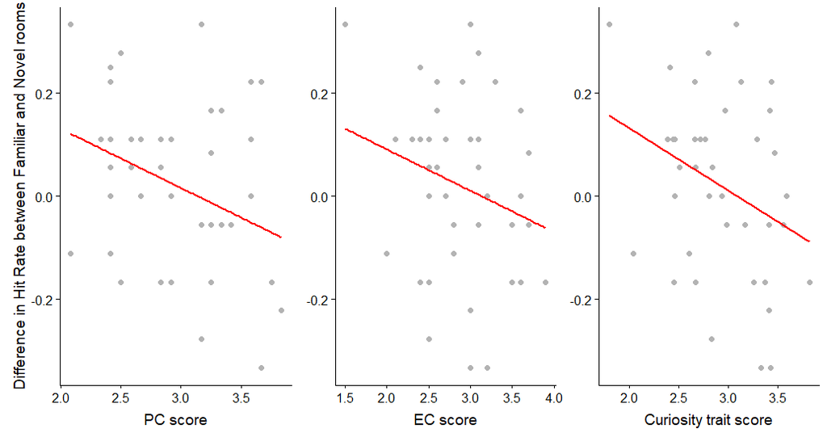

```r
cor.test(MemoryDifference$diffSeenHitInside, MemoryDifference$PC, method = "pearson")
cor.test(MemoryDifference$diffSeenHitInside, MemoryDifference$EC, method = "pearson")
cor.test(MemoryDifference$diffSeenHitInside, MemoryDifference$GN, method = "pearson")
```

[output not shown]

#### Source memory

```r
cor.test(MemoryDifference$diffContextAccuracyInside, MemoryDifference$PC, method = "pearson")
cor.test(MemoryDifference$diffContextAccuracyInside, MemoryDifference$EC, method = "pearson")
cor.test(MemoryDifference$diffContextAccuracyInside, MemoryDifference$GN, method = "pearson")
```

[output not shown]

### Outside the rooms

#### Recollection

```r
cor.test(MemoryDifference$diffSeenHitOutside, MemoryDifference$PC, method = "pearson")
cor.test(MemoryDifference$diffSeenHitOutside, MemoryDifference$EC, method = "pearson")
cor.test(MemoryDifference$diffSeenHitOutside, MemoryDifference$GN, method = "pearson")
```

[output not shown]

#### Source memory

```r
cor.test(MemoryDifference$diffContextAccuracyOutside, MemoryDifference$PC, method = "pearson")
cor.test(MemoryDifference$diffContextAccuracyOutside, MemoryDifference$EC, method = "pearson")
cor.test(MemoryDifference$diffContextAccuracyOutside, MemoryDifference$GN, method = "pearson")
```

[output not shown]